# A Quick Run-through of Some Selected Statistical Methods

## Mean

- **Definition:** Sum of all values divided by the number of observations.
- **Formula:** $\displaystyle \bar{x} = \frac{1}{n}\sum_{i=1}^n x_i$.
- **Interpretation:** Captures central tendency but is sensitive to outliers.

## Median

- **Definition:** Middle value separating the higher half from the lower half of an ordered dataset.
- **Formula:**
  - If $n$ odd: $\operatorname{med}(x)=x_{(\frac{n+1}{2})}$
  - If $n$ even: $\operatorname{med}=\tfrac{x_{(\frac{n}{2})}+x_{(\frac{n}{2}+1)}}{2}$.
- **Interpretation:** A robust center unaffected by extreme values.

## Mode

- **Definition:** Value(s) occurring most frequently in a dataset.
- **Identification:** Count frequencies; the highest‐frequency value(s) are the mode.
- **Interpretation:** Highlights the most common data point(s), useful for categorical or nominal data.

## Standard Deviation

- **Definition:** Square root of the variance; measures average deviation from the mean.
- **Formula:**
  - Population: $\sigma = \sqrt{\tfrac{1}{N}\sum_{i=1}^N (x_i - \mu)^2}$
  - Sample: $s = \sqrt{\tfrac{1}{n-1}\sum_{i=1}^n (x_i - \bar{x})^2}$.
- **Interpretation:** Indicates overall spread in the same units as the data.

## Interquartile Range (IQR)

- **Definition:** Difference between the third quartile ($Q_3$) and first quartile ($Q_1$).
- **Formula:** $\displaystyle \mathrm{IQR} = Q_3 - Q_1$.
- **Interpretation:** Spread of the middle 50%, robust to outliers.

## Pearson Correlation

- **Definition:** Measures linear association between two variables, ranging from –1 to +1.
- **Formula:**  
  $\displaystyle r = \frac{\sum_{i=1}^n (x_i - \bar{x})(y_i - \bar{y})}{\sqrt{\sum_{i=1}^n (x_i - \bar{x})^2}\,\sqrt{\sum_{i=1}^n (y_i - \bar{y})^2}}$.
- **Interpretation:** Values near ±1 indicate strong linear relationship; 0 means no linear correlation.

## Spearman Correlation

- **Definition:** Nonparametric measure of rank correlation, assessing monotonic relationships.
- **Formula:**  
  $\displaystyle \rho = 1 - \frac{6\sum_{i=1}^n d_i^2}{n(n^2-1)}$, where $d_i$ is the difference in ranks.
- **Interpretation:** Captures monotonic trends; robust to outliers and non‐linear patterns.

## Pearson vs. Spearman ??

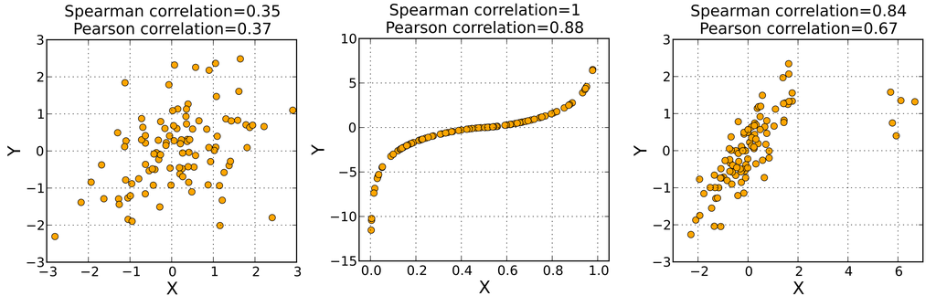

Source: https://commons.wikimedia.org/w/index.php?title=File:Spearman_fig2.svg&oldid=957852709.

# Regression-Type Modelling

# Simple Linear Regression

## Simple Regression: Model Specification

The simple linear regression model posits

$$y_i \;=\;\beta_0 \;+\;\beta_1\,x_i \;+\;\epsilon_i,$$

with random errors $\epsilon_i\sim N(0,\sigma^2)$.

## Simple Regression: Estimation

Ordinary least squares estimates $\hat{\beta}_0,\hat{\beta}_1$ by minimizing $\sum \epsilon_i^2$, yielding

$$\hat{\beta}_1 \;=\;\frac{\sum (x_i-\bar{x})(y_i-\bar{y})}{\sum (x_i-\bar{x})^2},
\quad
\hat{\beta}_0 = \bar{y}-\hat{\beta}_1\bar{x}.$$

# Multiple Linear Regression

## Multiple Regression: Model Specification

Multiple linear regression extends to (p) predictors:
$$y_i \;=\;\beta_0 \;+\;\sum_{k=1}^p \beta_k\,x_{ik} \;+\;\epsilon_i,$$

with $\epsilon_i\sim N(0,\sigma^2)$.

## Multiple Regression: Matrix Form and Inference

In matrix notation,

$$\mathbf{y} = \mathbf{X}\boldsymbol{\beta} + \boldsymbol{\epsilon},\quad \boldsymbol{\epsilon}\sim N(\mathbf{0}, \sigma^2I_p)$$

and the OLS solution is

$$\hat{\boldsymbol{\beta}} = (\mathbf{X}^\top\mathbf{X})^{-1}\,\mathbf{X}^\top\,\mathbf{y},$$

assuming full-rank $\mathbf{X}$ .

# Linear Models or General Linear Model

## (General) Linear Models

The (general) linear model compactly represents multiple (possibly multivariate) response regression as

$$\mathbf{Y} = \mathbf{X}\,\mathbf{B} + \mathbf{U},$$

where columns of $\mathbf{Y}$ are different dependent variables and $\mathbf{U}$ contains error terms .

## Linear Models: Hypothesis Testing

Linear hypotheses $H_0: \mathbf{C}\,\mathrm{vec}(\mathbf{B}) = \mathbf{d}$ are tested via F-statistics under normality of $\mathbf{U}$, using contrasts $\mathbf{C}$ to form test statistics .

# Generalized Linear Models (GLM)

## Generalized Linear Models: Model Components

A GLM has three components:

$$\begin{aligned}
&\textbf{RC:}\quad
f(\mathbf{y};\boldsymbol{\theta},\phi)
= \exp\!\Bigl\{\tfrac{\mathbf{y}^\top\boldsymbol{\theta} \;-\;\mathbf{1}^\top b(\boldsymbol{\theta})}{a(\phi)}
\;+\;\mathbf{1}^\top c(\mathbf{y},\phi)\Bigr\}, \\[6pt]
&\textbf{SC:}\quad
\boldsymbol{\eta} \;=\; X\,\boldsymbol{\beta},
\quad \eta_i = \mathbf{x}_i^\top\boldsymbol{\beta}, \\[4pt]
&\textbf{LF:}\quad
g(\boldsymbol{\mu}) \;=\;\boldsymbol{\eta},
\quad \boldsymbol{\mu} \;=\;g^{-1}(\boldsymbol{\eta}),
\quad \mu_i = E[Y_i].
\end{aligned}$$
where **Random component (RC)**, **Systematic component (SC)**, and **Link function (LF)**.

## Generalized Linear Models: Estimation

Parameters $\boldsymbol{\beta}$ are estimated by maximum likelihood via iteratively reweighted least squares, solving

$$\mathbf{X}^\top \mathbf{W} (\mathbf{y}-\boldsymbol{\mu}) = \mathbf{0},$$

where $\mathbf{W}$ is a weight matrix depending on $\mu_i$ and the variance function .

# Linear Mixed Effects Models (LMM)

## LMM: Model Specification

Linear mixed effects models incorporate fixed and random effects:

$$\mathbf{y} = \mathbf{X}\boldsymbol{\beta} + \mathbf{Z}\mathbf{b} + \boldsymbol{\epsilon},$$

with $\mathbf{b}\sim N(\mathbf{0},\mathbf{G})$ and $\boldsymbol{\epsilon}\sim N(\mathbf{0},\mathbf{R})$ .

## LMM: Estimation

Fixed effects $\boldsymbol{\beta}$ and variance components $\mathbf{G},\mathbf{R}$ are typically estimated by restricted maximum likelihood (REML), and random effects $\mathbf{b}$ by best linear unbiased prediction (BLUP) .

# Generalized Linear Mixed Effects Models (GLLM)

## GLLM: Model Specification

GLMMs extend GLMs by adding random effects into the linear predictor:
$$g\bigl(E[Y_i \mid \mathbf{b}]\bigr) \;=\;\mathbf{x}_i^\top\boldsymbol{\beta} + \mathbf{z}_i^\top\mathbf{b},
\quad \mathbf{b}\sim N(\mathbf{0},\mathbf{G}).$$

## GLLM: Estimation

Estimation typically employs Laplace approximation or adaptive Gauss–Hermite quadrature to approximate the marginal likelihood
$$\int f(\mathbf{y}\mid \mathbf{b})\,f(\mathbf{b})\,d\mathbf{b}.$$

# Generalized Additive Models (GAM)

## GAM: Model Specification

Generalized additive models replace linear terms with smooth functions:
$$y_i \;=\;\beta_0 + \sum_{j=1}^p f_j(x_{ij}) + \epsilon_i,$$

where each $f_j$ is a nonparametric smooth function estimated from the data .

## GAM: Estimation

The smooth functions $f_j$ are estimated using penalized regression splines via backfitting or penalized likelihood, controlling smoothness with penalties on the wiggliness of $f_j$ .

# Some Commonly Used Smooth Functions

## Thin Plate Regression Splines

$$f(\mathbf{x}) = \sum_{j=1}^k \alpha_j\,\phi_j(\mathbf{x}),$$

with roughness penalty

$$J[f] = \iint \Bigl((\partial_{xx}f)^2 + 2(\partial_{xy}f)^2 + (\partial_{yy}f)^2\Bigr)\,dx\,dy.$$

## Cubic Regression Splines

$$f(x) = \sum_{j=1}^k \beta_j\,B_j(x),$$

where $B_j$ are cubic B-spline basis functions, and the penalty is
$$\int [f''(x)]^2\,dx.$$

## P-Splines

$$f(x) = \sum_{j=1}^k \beta_j\,B_j(x),$$

with discrete difference penalty
$$\sum_{j=d+1}^k (\Delta^d \beta_j)^2,$$
where
$$\Delta^d \beta_j = \beta_j - \beta_{j-d}.$$

## Cyclic Cubic Regression Splines

Same as cubic splines but with periodicity constraints $f^{(m)}(x_1)=f^{(m)}(x_n)$ for $m=0,1$, and penalty
$$\int [f''(x)]^2\,dx.$$

## Adaptive Smoothers

$$\min_f \sum_i (y_i - f(x_i))^2 \;+\; \int \lambda(x)\,[f''(x)]^2\,dx,$$

where the smoothing weight $\lambda(x)$ varies over the domain.

## Low-Rank Duchon Splines

$$f(\mathbf{x}) = \sum_{j=1}^k \alpha_j\,\psi_j(\mathbf{x}),$$

with Fourier-domain penalty
$$\displaystyle \int \lvert\omega\rvert^m\,\lvert\hat f(\omega)\rvert^2\,d\omega.$$

## Tensor Product Smooths

$$f(x,z) = \sum_{i=1}^{k_1}\sum_{j=1}^{k_2} \alpha_{ij}\,B_i(x)\,C_j(z),$$

with separate penalties applied to each marginal bases $B_i$ and $C_j$.

## Interaction-Only Smooths

Same tensor product but **excludes** univariate smooths, so

$$f(x,z) = \sum_{i,j}\alpha_{ij}\,B_i(x)\,C_j(z),
\quad\text{no }f_1(x)\text{ or }f_2(z).$$

## Random Effect Smooths

$$f(g_i) = b_{g_i},
\quad \mathbf b\sim N(\mathbf0,\sigma^2\mathbf I),$$

equivalent to random intercepts with penalty $\mathbf b^\top\mathbf b$.

## Factor-By Smooths

$$f(x,\text{fac}_i)=\sum_{k=1}^L I(\text{fac}_i=k)\,f_k(x),$$

with one smooth per factor level sharing a penalty
$$\sum_k\int [f_k''(x)]^2\,dx.$$

## Markov Random Field Smooths

$$\text{Penalty} = \sum_{i\sim j} (f_i - f_j)^2,$$

where $i\sim j$ denotes spatial adjacency on areal units.

## Soap-Film Boundary Smooths

Basis functions $\psi_j$ satisfy boundary constraints over a domain $\Omega$, with penalty
$$\int_\Omega (\Delta f)^2\,dx.$$

## Splines on the Sphere

$$f(\theta,\phi)=\sum_{l=0}^L\sum_{m=-l}^l \alpha_{lm}\,Y_{lm}(\theta,\phi),$$

with penalty
$$\sum_{l,m} l(l+1)\,\alpha_{lm}^2.$$

## Gaussian Process Smooths

$$f(x)\sim\mathcal{GP}(0,\,k(x,x')),$$

where $k$ may be Matérn, exponential, etc., and the penalty is the RKHS norm $\|f\|^2_{\mathcal H}$.

## QR of My Presentations and Materials

[figure not shown]

**Thank you for listening ;)**